# Proyecto_R_IRIS

Valeria Solís

2025-04-23

# Carga de librerías

```r
library(readr)
library(ggplot2)
```

# Leer el dataset desde un archivo “.csv”

```
## ──────────────────────────────────────────────────────── Delimiter: "," chr
## (1): Species dbl (5): ...1, Sepal.Length, Sepal.Width, Petal.Length,
## Petal.Width
```

# Ver el dataset

```r
View(iris)
```

# Primera Parte: Carga y exploración de datos

## 1. Estructura del dataset

```r
str(iris)
```

```
## spc_tbl_ [150 × 6] (S3: spec_tbl_df/tbl_df/tbl/data.frame)
##  $ ...1        : num [1:150] 1 2 3 4 5 6 7 8 9 10 ...
##  $ Sepal.Length: num [1:150] 5.1 4.9 4.7 4.6 5 5.4 4.6 5 4.4 4.9 ...
##  $ Sepal.Width : num [1:150] 3.5 3 3.2 3.1 3.6 3.9 3.4 3.4 2.9 3.1 ...
##  $ Petal.Length: num [1:150] 1.4 1.4 1.3 1.5 1.4 1.7 1.4 1.5 1.4 1.5 ...
##  $ Petal.Width : num [1:150] 0.2 0.2 0.2 0.2 0.2 0.4 0.3 0.2 0.2 0.1 ...
##  $ Species     : chr [1:150] "setosa" "setosa" "setosa" "setosa" ...
##  - attr(*, "spec")=
##   .. cols(
##   ..   ...1 = col_double(),
##   ..   Sepal.Length = col_double(),
##   ..   Sepal.Width = col_double(),
##   ..   Petal.Length = col_double(),
##   ..   Petal.Width = col_double(),
##   ..   Species = col_character()
##   .. )
##  - attr(*, "problems")=<externalptr>
```

## 2. Primeras y últimas 6 filas del dataset

```r
head(iris)
```

```
## # A tibble: 6 × 6
##    ...1 Sepal.Length Sepal.Width Petal.Length Petal.Width Species
##   <dbl>        <dbl>       <dbl>        <dbl>       <dbl> <chr>
## 1     1          5.1         3.5          1.4         0.2 setosa
## 2     2          4.9         3            1.4         0.2 setosa
## 3     3          4.7         3.2          1.3         0.2 setosa
## 4     4          4.6         3.1          1.5         0.2 setosa
## 5     5          5           3.6          1.4         0.2 setosa
## 6     6          5.4         3.9          1.7         0.4 setosa
```

```r
tail(iris)
```

```
## # A tibble: 6 × 6
##    ...1 Sepal.Length Sepal.Width Petal.Length Petal.Width Species
##   <dbl>        <dbl>       <dbl>        <dbl>       <dbl> <chr>
## 1   145          6.7         3.3          5.7         2.5 virginica
## 2   146          6.7         3            5.2         2.3 virginica
## 3   147          6.3         2.5          5           1.9 virginica
## 4   148          6.5         3            5.2         2   virginica
## 5   149          6.2         3.4          5.4         2.3 virginica
## 6   150          5.9         3            5.1         1.8 virginica
```

## 3. Tipo de datos por columna

```r
sapply(iris, typeof)
```

```
##         ...1 Sepal.Length  Sepal.Width Petal.Length  Petal.Width      Species
##     "double"     "double"     "double"     "double"     "double"  "character"
```

```r
sapply(iris, is.logical)
```

```
##         ...1 Sepal.Length  Sepal.Width Petal.Length  Petal.Width      Species
##        FALSE        FALSE        FALSE        FALSE        FALSE        FALSE
```

```r
sapply(iris, is.numeric)
```

```
##         ...1 Sepal.Length  Sepal.Width Petal.Length  Petal.Width      Species
##         TRUE         TRUE         TRUE         TRUE         TRUE        FALSE
```

## 4. Dimensiones del dataset

```r
dim(iris)
```

```
## [1] 150   6
```

## 5. Verificación de valores faltantes

### NA = valor faltante, NaN = resultado inválido (e.g., 0/0)

### ¿Hay algún NA?

```r
any(is.na(iris))
```

```
## [1] FALSE
```

### Cantidad de NA por columna

```r
colSums(is.na(iris))
```

```
##         ...1 Sepal.Length  Sepal.Width Petal.Length  Petal.Width      Species
##            0            0            0            0            0            0
```

### Verificar NaN solo en columnas numéricas

```r
solo_numericas <- sapply(iris, is.numeric)
sum(is.nan(as.matrix(iris[, solo_numericas])))
```

```
## [1] 0
```

# Segunda Parte: Estadísticas descriptivas básicas

## 1-¿Cuál es el valor mínimo de una variable numérica en el dataset?

```r
min(iris$Petal.Length)
```

```
## [1] 1
```

## 2-¿Cuál es el valor máximo de una variable numérica en el dataset?

```r
max(iris$Petal.Length)
```

```
## [1] 6.9
```

## 3-¿Cuál es la media de una variable numérica en el dataset?

```r
mean(iris$Petal.Length)
```

```
## [1] 3.758
```

## 4-¿Cuál es la mediana de una variable numérica en el dataset?

```r
median(iris$Petal.Length)
```

```
## [1] 4.35
```

## 5-¿Cuál es la desviación estándar de una variable numérica en el dataset?

```r
sd(iris$Petal.Length)
```

```
## [1] 1.765298
```

## 6-¿Cuál es el rango (diferencia entre el máximo y el mínimo) de una variable numérica en el dataset?

```r
range_value <- max(iris$Petal.Length) - min(iris$Petal.Length)
range_value
```

```
## [1] 5.9
```

## 7-¿Cuál es el rango intercuartílico (IQR) de una variable numérica en el dataset?

```r
data(iris)
IQR(iris$Sepal.Length)
```

```
## [1] 1.3
```

## 8-¿Cuál es la moda de una variable categórica en el dataset?

```r
species_counts <- table(iris$Species)
most_common_species <- names(which.max(species_counts))
most_common_species
```

```
## [1] "setosa"
```

# Tercera Parte: Manipulación de datos

## 1-Calcular el porcentaje de valores faltantes en cada columna de un dataset.

```r
porcentaje_faltantes <- sapply(iris, function(columna) {
  sum(is.na(columna)) / length(columna) * 100
})
porcentaje_faltantes
```

```
## Sepal.Length  Sepal.Width Petal.Length  Petal.Width      Species
##            0            0            0            0            0
```

## 2-¿Cómo puedes eliminar las filas que contienen valores faltantes?

```r
datos_limpios <- na.omit(iris)
```

## 3-¿Cómo ordenar los valores de una columna numérica (orden decreciente)?

```r
# Seleccionar solo las columnas numéricas
data(iris)
numericas <- sapply(iris, is.numeric)
print (numericas)
```

```
## Sepal.Length  Sepal.Width Petal.Length  Petal.Width      Species
##         TRUE         TRUE         TRUE         TRUE        FALSE
```

```r
# Obtener nombres de columnas numéricas
col_numericas <- names(iris)[numericas]
print(col_numericas)
```

```
## [1] "Sepal.Length" "Sepal.Width"  "Petal.Length" "Petal.Width"
```

```r
# Ordenar por todas las columnas numéricas (en orden de aparición)
iris_numericas <- iris[, col_numericas]
print(head(iris_numericas))
```

```
##   Sepal.Length Sepal.Width Petal.Length Petal.Width
## 1          5.1         3.5          1.4         0.2
## 2          4.9         3.0          1.4         0.2
## 3          4.7         3.2          1.3         0.2
## 4          4.6         3.1          1.5         0.2
## 5          5.0         3.6          1.4         0.2
## 6          5.4         3.9          1.7         0.4
```

```r
# Utilizando la función sort
sort(iris$Sepal.Length, decreasing = TRUE)
```

```
##   [1] 7.9 7.7 7.7 7.7 7.7 7.6 7.4 7.3 7.2 7.2 7.2 7.1 7.0 6.9 6.9 6.9 6.9 6.8
##  [19] 6.8 6.8 6.7 6.7 6.7 6.7 6.7 6.7 6.7 6.7 6.6 6.6 6.5 6.5 6.5 6.5 6.5 6.4
##  [37] 6.4 6.4 6.4 6.4 6.4 6.4 6.3 6.3 6.3 6.3 6.3 6.3 6.3 6.3 6.3 6.2 6.2 6.2
##  [55] 6.2 6.1 6.1 6.1 6.1 6.1 6.1 6.0 6.0 6.0 6.0 6.0 6.0 5.9 5.9 5.9 5.8 5.8
##  [73] 5.8 5.8 5.8 5.8 5.8 5.7 5.7 5.7 5.7 5.7 5.7 5.7 5.7 5.6 5.6 5.6 5.6 5.6
##  [91] 5.6 5.5 5.5 5.5 5.5 5.5 5.5 5.5 5.4 5.4 5.4 5.4 5.4 5.4 5.3 5.2 5.2 5.2
## [109] 5.2 5.1 5.1 5.1 5.1 5.1 5.1 5.1 5.1 5.1 5.0 5.0 5.0 5.0 5.0 5.0 5.0 5.0
## [127] 5.0 5.0 4.9 4.9 4.9 4.9 4.9 4.9 4.8 4.8 4.8 4.8 4.8 4.7 4.7 4.6 4.6 4.6
## [145] 4.6 4.5 4.4 4.4 4.4 4.3
```

## 4-¿Cómo puedes seleccionar solo algunas columnas de un dataset?

```r
iris[, c("Sepal.Length", "Petal.Length")]
```

```
##     Sepal.Length Petal.Length
## 1            5.1          1.4
## 2            4.9          1.4
## 3            4.7          1.3
## 4            4.6          1.5
## 5            5.0          1.4
## 6            5.4          1.7
## 7            4.6          1.4
## 8            5.0          1.5
## 9            4.4          1.4
## 10           4.9          1.5
## 11           5.4          1.5
## 12           4.8          1.6
## 13           4.8          1.4
## 14           4.3          1.1
```

[output cut: 136 more lines]

```r
print(iris)
```

```
##     Sepal.Length Sepal.Width Petal.Length Petal.Width    Species
## 1            5.1         3.5          1.4         0.2     setosa
## 2            4.9         3.0          1.4         0.2     setosa
## 3            4.7         3.2          1.3         0.2     setosa
## 4            4.6         3.1          1.5         0.2     setosa
## 5            5.0         3.6          1.4         0.2     setosa
## 6            5.4         3.9          1.7         0.4     setosa
## 7            4.6         3.4          1.4         0.3     setosa
## 8            5.0         3.4          1.5         0.2     setosa
## 9            4.4         2.9          1.4         0.2     setosa
## 10           4.9         3.1          1.5         0.1     setosa
## 11           5.4         3.7          1.5         0.2     setosa
## 12           4.8         3.4          1.6         0.2     setosa
## 13           4.8         3.0          1.4         0.1     setosa
## 14           4.3         3.0          1.1         0.1     setosa
```

[output cut: 136 more lines]

## 5-¿Cómo podría agregar una nueva columna que sea el producto de dos variables numéricas existentes en su dataset?

```r
iris$Producto <- iris$Sepal.Length * iris$Petal.Length
iris
```

```
##     Sepal.Length Sepal.Width Petal.Length Petal.Width    Species Producto
## 1            5.1         3.5          1.4         0.2     setosa     7.14
## 2            4.9         3.0          1.4         0.2     setosa     6.86
## 3            4.7         3.2          1.3         0.2     setosa     6.11
## 4            4.6         3.1          1.5         0.2     setosa     6.90
## 5            5.0         3.6          1.4         0.2     setosa     7.00
## 6            5.4         3.9          1.7         0.4     setosa     9.18
## 7            4.6         3.4          1.4         0.3     setosa     6.44
## 8            5.0         3.4          1.5         0.2     setosa     7.50
## 9            4.4         2.9          1.4         0.2     setosa     6.16
## 10           4.9         3.1          1.5         0.1     setosa     7.35
## 11           5.4         3.7          1.5         0.2     setosa     8.10
## 12           4.8         3.4          1.6         0.2     setosa     7.68
## 13           4.8         3.0          1.4         0.1     setosa     6.72
## 14           4.3         3.0          1.1         0.1     setosa     4.73
```

[output cut: 136 more lines]

## 6-Cambiar todos los nombres de las columnas del dataset

```r
names(iris) <- c("Largo_Sepalo", "Ancho_Sepalo", "Largo_Petalo", "Ancho_Petalo", "Especie", "Producto")
head(iris)
```

```
##   Largo_Sepalo Ancho_Sepalo Largo_Petalo Ancho_Petalo Especie Producto
## 1          5.1          3.5          1.4          0.2  setosa     7.14
## 2          4.9          3.0          1.4          0.2  setosa     6.86
## 3          4.7          3.2          1.3          0.2  setosa     6.11
## 4          4.6          3.1          1.5          0.2  setosa     6.90
## 5          5.0          3.6          1.4          0.2  setosa     7.00
## 6          5.4          3.9          1.7          0.4  setosa     9.18
```

# Cuarta Parte: Análisis comparativo de datos

## 1-Visualizar la distribución de una variable numérica para diferentes categorías de una variable seleccionada por usted usando un boxplot.

### Distribución de Sepal.Length para una especie.

```r
names(iris)
```

```
## [1] "Largo_Sepalo" "Ancho_Sepalo" "Largo_Petalo" "Ancho_Petalo" "Especie"
## [6] "Producto"
```

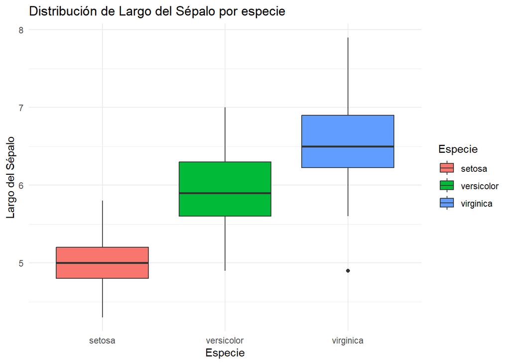

```r
ggplot(iris, aes(x = Especie, y = Largo_Sepalo, fill = Especie)) +
  geom_boxplot() +
  labs(title = "Distribución de Largo del Sépalo por especie",
       x = "Especie", y = "Largo del Sépalo") +
  theme_minimal()
```

## 2-Calcular la matriz de correlación. Investigar que es el coeficiente de correlación de Pearson e interpretar uno de los coeficientes de la matriz.

### Calcular la matriz de correlación

```r
iris_numericas <- iris[, sapply(iris, is.numeric)]
cor_matrix <- cor(iris_numericas)
cor_matrix
```

```
##              Largo_Sepalo Ancho_Sepalo Largo_Petalo Ancho_Petalo   Producto
## Largo_Sepalo    1.0000000   -0.1175698    0.8717538    0.8179411  0.9344079
## Ancho_Sepalo   -0.1175698    1.0000000   -0.4284401   -0.3661259 -0.3341129
## Largo_Petalo    0.8717538   -0.4284401    1.0000000    0.9628654  0.9831256
## Ancho_Petalo    0.8179411   -0.3661259    0.9628654    1.0000000  0.9372697
## Producto        0.9344079   -0.3341129    0.9831256    0.9372697  1.0000000
```

### Interpretar uno de los coeficientes de la matriz: Tomando Sepal.Length y Petal.Length, veremos que existe una correlación significativa ya que el resultado es un valor de 0.87, esto quiere decir que, cuando una variable aumenta (por ejemplo, Sepal.Length), la otra también tiende a aumentar (Petal.Length).A partir de este dato podríamos predecir la longitud del pétalo a partir de la longitud del sépalo, dado que ambas tienen correlación.

## 3-Seleccionar una variable numérica y construir un gráfico de densidad para analizar su distribución.

### Variable Sepal.Length

```r
names(iris)
```

```
## [1] "Largo_Sepalo" "Ancho_Sepalo" "Largo_Petalo" "Ancho_Petalo" "Especie"
## [6] "Producto"
```

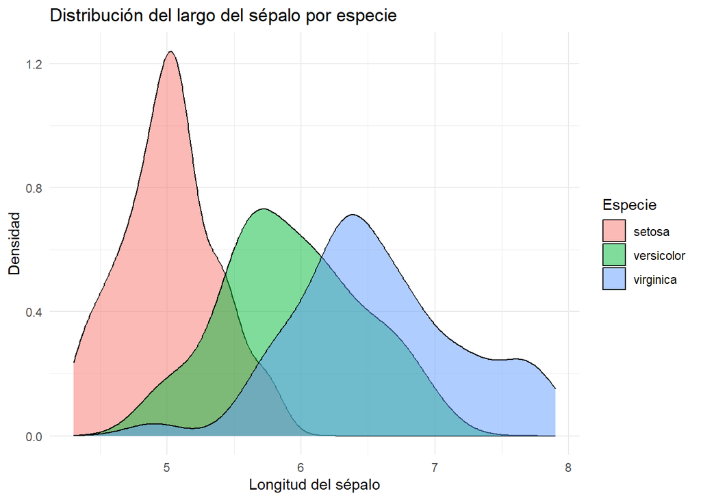

```r
ggplot(iris, aes(x = Largo_Sepalo, fill = Especie)) +
  geom_density(alpha = 0.5) +
  labs(
    title = "Distribución del largo del sépalo por especie",
    x = "Longitud del sépalo",
    y = "Densidad"
  ) +
  theme_minimal()
```

## 4- Seleccionar dos variables numéricas y crear un gráfico de dispersión para estudiar la relación entre ambas variables. ¿Observa algún patrón en el gráfico interesante? Explique ese patrón en caso de existir. Puede probar con otras variables.

### Relación entre Petal.Length y Petal.Width

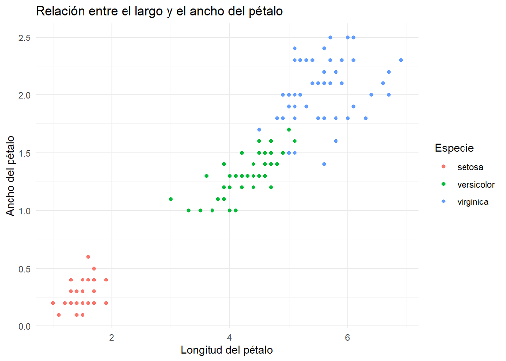

```r
ggplot(iris, aes(x = Largo_Petalo, y = Ancho_Petalo, color = Especie)) +
  geom_point() +
  labs(title = "Relación entre el largo y el ancho del pétalo",
       x = "Longitud del pétalo",
       y = "Ancho del pétalo") +
  theme_minimal()
```

### Patrones: En las especies versicolor y virginica, observamos que conforme aumenta la longitud del pétalo, también tiende a aumentar su ancho. Las flores de setosa tienen tanto un Petal.Length como un Petal.Width más pequeños en comparación con las otras especies. Según el análisis setosa tiene una morfología distinta al resto de especies.